# Final Project: R Reference Guide

Desiree Smith

12/12/2021

# R Reference Guide

## Loading Data and Packages

```r
require(here)
require(palmerpenguins)
library(palmerpenguins)

ginkgo = read.csv(here("data", "ginkgo_data_2021.csv"))
```

## Data Structures

### c()

```r
# Create a vector of numbers:
num_vec  = c(1, 4, 8, 9, 13)
```

### length()

- Helps to determine and set the length of vectors and factors

```r
length(ginkgo$max_width)
```

```
## [1] 756
```

### matrix()

- Helps to create a 2D data structure using your data. It can be created from vectors.

```r
matrix(ginkgo$max_width, byrow= 3, ncol= 6)
```

```
##         [,1] [,2] [,3] [,4]  [,5] [,6]
##   [1,]  71.0   64   55   62  65.0   70
##   [2,]  63.0   56   51   57  59.0   63
##   [3,]  70.0   50   56   46  54.0   62
##   [4,]  56.0   55   59   60  63.0   61
##   [5,]  58.0   55   53   81  94.0   75
##   [6,]  82.0   86   79   93  88.0   76
##   [7,]  71.0   91   71   82  65.0   83
##   [8,]  73.0  102   78   88  81.0   70
##   [9,]  80.0   96   80   82  86.0   87
##  [10,]  89.0   69   93   98  81.0   79
##  [11,]  82.0   85   81   59  53.0   83
##  [12,]  80.0   77   81   76  82.0   81
##  [13,]  77.0   68   41   70  68.0   80
##  [14,]  89.0   90   71   64  55.0   62
```

[output cut: 112 more lines]

### data.frame()

- Data frame is a way of storing data in R and how to structure it. They have the same number of rows.

```r
ginkgo_df= data.frame(ginkgo$max_width,
                      ginkgo$max_depth)
```

- **nrow** is used to return the number of rows of the specified matrix and **ncol** is used to return the number of columns.

```r
nrow(ginkgo_df)
```

```
## [1] 756
```

```r
ncol(ginkgo_df)
```

```
## [1] 2
```

- dim is used to return/sets the dimension of the matrix. It shows the amount of rows and columns

```r
dim(ginkgo_df)
```

```
## [1] 756   2
```

## Subsetting

- Is a way to select variable and observations.You can use subset to specify the rows and columns you want to select in the data frame. You can subset by position and data frame as well.

### subsetting by name

ginkgo$max_width

### subsetting by position

ginkgo[1,] ginkgo[2,3] ginkgo[,3]

### subsetting by specific group

subset(penguins, species == “Adelie”)

## Numerical Data Exploration

- The summary function helps to put together a summary of statistics of data and model.

```r
summary(ginkgo)
```

```
##     site_id      seeds_present     max_width        max_depth
##  Min.   : 1896   Mode :logical   Min.   : 16.00   Min.   : 19.00
##  1st Qu.: 3703   FALSE:636       1st Qu.: 63.00   1st Qu.: 43.00
##  Median : 6066   TRUE :120       Median : 74.00   Median : 51.00
##  Mean   : 6079                   Mean   : 74.34   Mean   : 58.51
##  3rd Qu.: 7206                   3rd Qu.: 85.00   3rd Qu.: 66.00
##  Max.   :12982                   Max.   :130.00   Max.   :145.00
##
##   notch_depth    petiole_length
##  Min.   : 0.00   Min.   :  8.00
##  1st Qu.: 0.00   1st Qu.: 34.00
##  Median : 0.00   Median : 47.00
##  Mean   : 2.99   Mean   : 48.25
##  3rd Qu.: 4.00   3rd Qu.: 60.00
##  Max.   :49.00   Max.   :113.00
##                  NA's   :4
```

```r
summary(ginkgo$max_width)
```

```
##    Min. 1st Qu.  Median    Mean 3rd Qu.    Max.
##   16.00   63.00   74.00   74.34   85.00  130.00
```

- mean () calculates the mean of the data you specifies and sd() helps to calculates the standard deviation.

```r
mean(ginkgo$max_width)
```

```
## [1] 74.33823
```

```r
sd(ginkgo$max_width)
```

```
## [1] 16.4203
```

## Graphical Data Exploration

### Creating a graph

- col = can be used to add color to your graph
- main = allows you to create a title for the graph
- xlab = and ylab = are used to label the x and y axis
- xlim = and ylim = set the limits of the x and y axis
- pch = allows you to change the shape of your symbol in scatterplots and other graphics.
- cex = allows you to change the size of your symbol

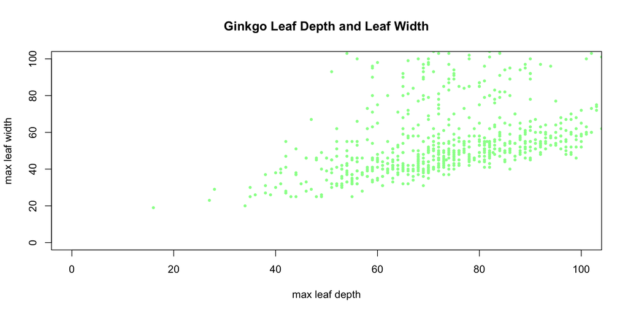

```r
ginkgo = read.csv(here("data",
                       "ginkgo_data_2021.csv"))


 plot(max_depth ~ max_width,
      data = ginkgo,
      xlim = c(0,100),
      ylim = c(0, 100),
  main = "Ginkgo Leaf Depth and Leaf Width",
  ylab = "max leaf width",
  xlab = "max leaf depth",
  col = "palegreen",
  pch = 20, cex = 0.75)
```

- breaks = is used to control the number of bars, cells or bins in a histogram

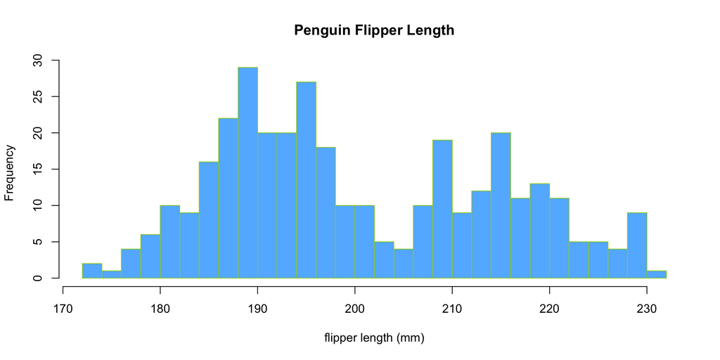

```r
hist(penguins$flipper_length_mm,
     main = "Penguin Flipper Length",
     xlab = "flipper length (mm)",
     col = "steelblue1",
     border = "yellowgreen",
     breaks = 40)
```

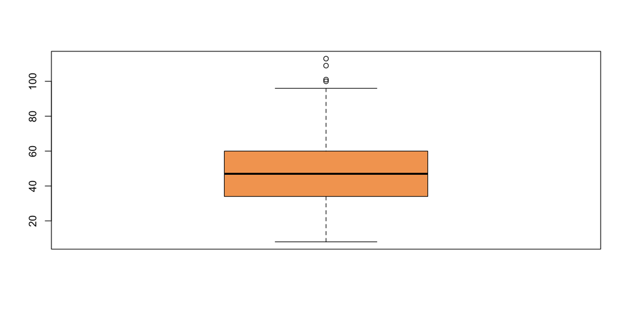

```r
boxplot(ginkgo$petiole_length, col = "sandybrown")
```

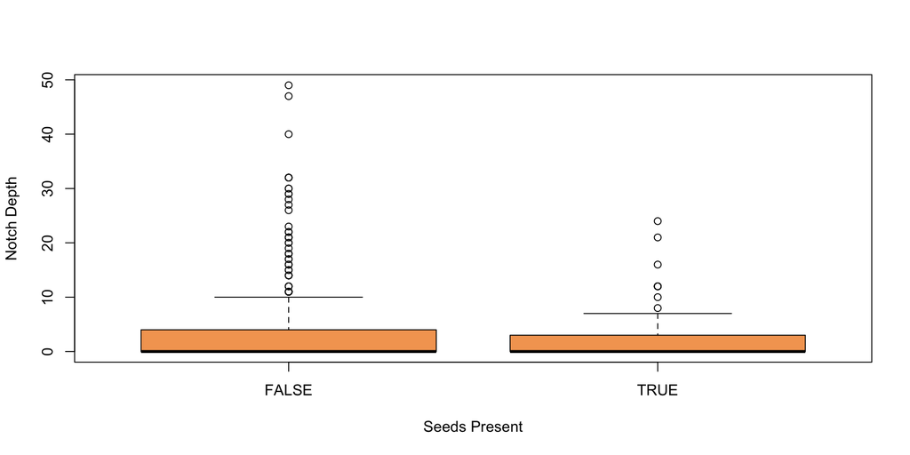

```r
boxplot(notch_depth ~ seeds_present ,
        data = ginkgo,
        ylab = "Notch Depth",
        xlab = "Seeds Present",
        col = "sandybrown")
```

- par(mfrow = c() creates a grid to to display your figures. For example, if you want two figures on the top and two at the bottom you use par(mfrow = c(2,2))

### 4-panel figure of Histogram

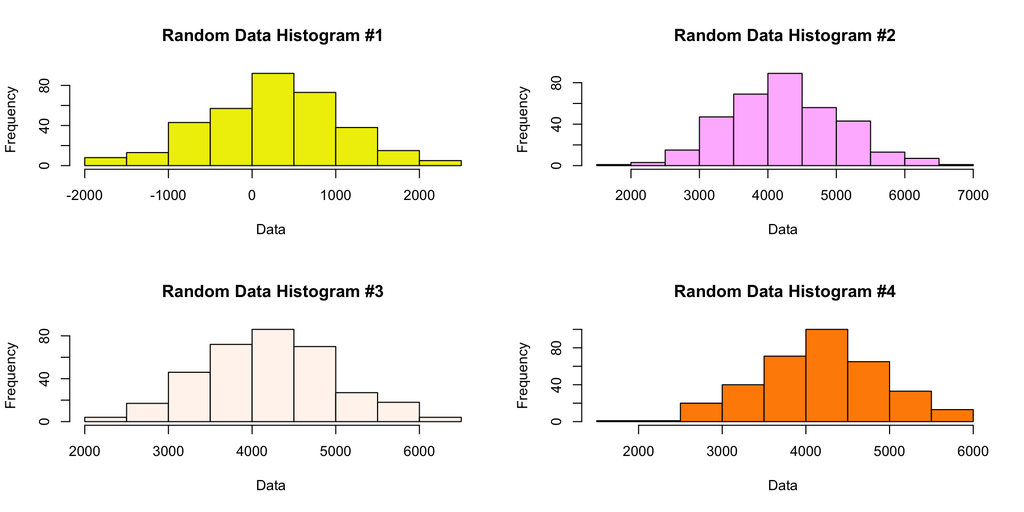

```r
dat_1 = rnorm(n = 344, mean = 202, sd = 802)
dat_2 = rnorm(n = 344, mean = 4202, sd = 802)
dat_3 = rnorm(n = 344, mean = 4202, sd = 802)
dat_4 = rnorm(n = 344, mean = 4202, sd = 802)

par(mfrow = c(2,2))

hist(dat_1,
     main = "Random Data Histogram #1",
     xlab = "Data ",
     col = "yellow2")
hist(dat_2,
     main = "Random Data Histogram #2",
     xlab = "Data ",
     col = "plum1")
hist(dat_3,
     main = "Random Data Histogram #3",
     xlab = "Data ",
     col = "seashell")
hist(dat_4,
     main = "Random Data Histogram #4",
     xlab = "Data ",
     col = "darkorange")
```

## Distribution Functions

- dnorm = density function of the normal distribution

```r
dnorm(6, mean = 10.4, sd = 2.4)
```

```
## [1] 0.03096298
```

- pnorm = distribution function

```r
pnorm(1.2, mean = 2, sd = 2)
```

```
## [1] 0.3445783
```

- qnorm = quantile function

```r
qnorm(0.85,mean=70,sd=3)
```

```
## [1] 73.1093
```

- dbinom(x, size, prob, log = FALSE)

```r
dbinom(3, 4, 0.75, log = FALSE)
```

```
## [1] 0.421875
```

- pbinom(q, size, prob, lower.tail = TRUE, log.p = FALSE)

```r
pbinom(3, 4, 0.75,lower.tail = TRUE,
       log.p = FALSE )
```

```
## [1] 0.6835937
```

- qbinom(p, size, prob, lower.tail = TRUE, log.p = FALSE)

```r
qbinom(.10, size=10, prob=.4)
```

```
## [1] 2
```